# Project Two

Kelly Goles

May 16, 2018

## **Executive Summary**

The following report outlines five prediction models wich use data colloected from the *Human Activity Recognition Using Smartphones Dataset*, to predict the activity being performed by the participants. The obtained dataset has been randomly partitioned into two sets, where 70% of the volunteers was selected for generating the training data(training.csv) and 30% the test data(testing.csv). Our models were trained based on parsed data from the training data, and will be tested against the training data. The models used include: randomForest, Classification and Regression Trees (CART), and Multinomial Logistic Regression with Cross Validation.

## **Cleaning the Code**

Make sure you are in the working directory which contains both the training.csv and the testing.csv.

Install the following packages: install.packages(“caret”) install.packages(“confusionMatrix”) install.packages(“rpart”) install.packages(“tree”) install.packages(“randomForest”)

##### **Import Data**

```r
Data<- "training.csv"
Table <- read.csv(Data)
Test<- "testing.csv"
Testt <- read.csv(Test)
```

Now we begin the cleaning process We deceided we are going to clean the Test Data first since it contains only 20 rows instead a few thousand and we can also understand which columns will not be needed since it contains columns that are all NAs.

##### **Delete Columns that contain only NAs**

```r
Testc <- Testt[, colSums(is.na(Testt)) != nrow(Testt)]
```

Now we will delete the columns we think are not important -We believe the three timestamp columns should be deleted since all they tell us in the time and not activity the person is doing - We believe the new window column is not important since in the test data they all are equal to no - We get rid of the column labeled X since it only tells us what observation it is and this is already shown by the corresponding row number for that observation

##### **Delete unwanted Columns**

```r
Testc2 <- Testc[, -3:-6]
Testc2 <- Testc2[, -1]
```

Our next intention is to match the columns of the Test Data with the columns of the Training Data. However, first we must save the classe column in the training data since it contains the solution to the Training Data -We renamed the column Answer

##### **Save Classe**

```r
Answer <- Table[, 160]
```

We find which columnns have the same names in both the new Test Data (cleaned) and the Training Data

##### **Find Column Names’ Intersection**

```r
Colc <- intersect(colnames(Table), colnames(Testc2))
```

We will now use these intersection of the column names to get rid of the columns in both Test Data and Training Data that are not the same -This also helps in regard to when we predict using our models becasue we know we have the same columns in both the Test Data and Training Data

##### **Delete non equivalent column names**

```r
Tablec <- Table[, Colc]
Testc3 <- Testc2[, Colc]
```

Finally, We need to add the Answer column back into Training Data so that when we run the models, the solutions are within the data frame.

##### **Add Answer Column Back**

```r
Tablec2 <- cbind(Tablec, Answer)
```

Quick Removal of unneeded data frames

##### **Remove data frames**

```r
rm(Testt)
rm(Table)
rm(Testc2)
rm(Testc)
```

## **randomForest Model: Matt Tizik**

I decided to do a random forest for my modeling method

First, I am going to partition the data 80% Training and 20% Testing in order to see how well my random forest model will work

##### **Partition**

```r
Training1 <- sample(1:nrow(Tablec2), size= .8* nrow(Tablec2))

TrainingData <- Tablec2[Training1, ]
TestData <- Tablec2[-Training1, ]
```

Second, I am going to run my random forest model on my training set with the solutions being the column titled Answer -I am using 200 trees instead of the default 500 since it is faster, less stressful on the computer, and more than enough diversifiction for the data -I am using 10 variables at each split to accomidate the reduction in number of trees -Using 10 out of 53 variables at each split should not over teach my model or complicate it too much

##### **Random Forest**

```r
library(randomForest)
TrainD1 <- randomForest(Answer ~ . , data= TrainingData, importance= T, ntree=200, mtry = 10)
```

##### **CMatrix and Statistics**

```
##
## Call:
##  randomForest(formula = Answer ~ ., data = TrainingData, importance = T,      ntree = 200, mtry = 10)
##                Type of random forest: classification
##                      Number of trees: 200
## No. of variables tried at each split: 10
##
##         OOB estimate of  error rate: 0.19%
## Confusion matrix:
##      A    B    C    D    E  class.error
## A 4470    0    0    0    0 0.0000000000
## B    3 3033    0    0    0 0.0009881423
## C    0   10 2699    0    0 0.0036913990
## D    0    0   10 2569    2 0.0046493607
## E    0    0    0    5 2896 0.0017235436
```

We see that we had an error rate of .19% and we miss classified 30 of the 15697 observations -Solid and as stated in our most recent class we don’t want to low of an in sample error becasue it may hurt our out of sample error

##### **Prediction on my Test data**

Now we will see how my Random Forest did in regard to the testing data which I had partitioned -20% of original Training Data

```r
Predict1 <- predict(TrainD1, TestData)
```

```
CMatrix<- table(Predict1, TestData$Answer)
```

##### **Prediction on Real Test Data**

Now we will use the random Forest model to predict the Class of the Test Data

```r
Solution <- predict(TrainD1, Testc3)
```

##### **Solution**

Here is a table of the answers

```
##  1  2  3  4  5  6  7  8  9 10 11 12 13 14 15 16 17 18 19 20
##  B  A  B  A  A  E  D  B  A  A  B  C  B  A  E  E  A  B  B  B
## Levels: A B C D E
```

##### **Final Table of Test Data**

We will combine it with the Test data as the last column so that it is comparable to the Cleaned Training Data

Test_Solution_Table <- cbind(Testc3, Solution) View(Test_Solution_Table)

## **Classification and Regression Trees Model: Kelly Goles**

##### **Set Working Directory and load test&training data**

```r
setwd("C:/Users/Student/Desktop")
TrainD <-read.csv("training.csv")
TestD <-read.csv("testing.csv")
```

##### **Delete Columns that only contain NA**

```r
Testc <- TestD[, colSums(is.na(TestD)) != nrow(TestD)]
Testc2 <- Testc[, -2:-7]
```

##### **Value that contains answers to training data set**

```r
Answer <- TrainD[, 160]
```

##### **Find columns that are in both TrainD and Testc**

```r
Colc <- intersect(colnames(TrainD), colnames(Testc2))
```

##### **Omit columns that contain:**

```r
Tablec <- TrainD[, Colc]
Testc3 <- Testc2[, Colc]
```

##### **Add Answers back into data**

```r
Tablec2 <- cbind(Tablec, Answer)
```

```r
Tablec4 <- Tablec2[,-c(1)]
```

##### **Set Seed**

```r
set.seed(123)
```

##### **Partition training data**

```r
alpha     <- 0.8
inTrain   <- sample(1:nrow(Tablec2), alpha * nrow(Tablec2))
train.set <- Tablec2[inTrain,]
test.set  <- Tablec2[-inTrain,]
```

##### **Install Tree Packages**

```r
library(tree)
```

##### **Tree Model to Regress Trainig Data against classification**

```r
tree.model <-tree(Answer ~ . , data=train.set)
tree.model
```

```
## node), split, n, deviance, yval, (yprob)
##       * denotes terminal node
##
##  1) root 15697 49820 A ( 0.2855 0.1948 0.1723 0.1635 0.1840 )
##    2) X < 9377.5 7538 10180 A ( 0.5945 0.4055 0.0000 0.0000 0.0000 )
##      4) X < 5581.5 4481     0 A ( 1.0000 0.0000 0.0000 0.0000 0.0000 ) *
##      5) X > 5581.5 3057     0 B ( 0.0000 1.0000 0.0000 0.0000 0.0000 ) *
##    3) X > 9377.5 8159 17910 E ( 0.0000 0.0000 0.3314 0.3146 0.3540 )
##      6) X < 16015.5 5271  7304 C ( 0.0000 0.0000 0.5130 0.4870 0.0000 )
##       12) X < 12799.5 2704     0 C ( 0.0000 0.0000 1.0000 0.0000 0.0000 ) *
##       13) X > 12799.5 2567     0 D ( 0.0000 0.0000 0.0000 1.0000 0.0000 ) *
##      7) X > 16015.5 2888     0 E ( 0.0000 0.0000 0.0000 0.0000 1.0000 ) *
```

```r
summary(tree.model)
```

```
##
## Classification tree:
## tree(formula = Answer ~ ., data = train.set)
## Variables actually used in tree construction:
## [1] "X"
## Number of terminal nodes:  5
## Residual mean deviance:  0 = 0 / 15690
## Misclassification error rate: 0 = 0 / 15697
```

##### **Distributional Prediction**

```r
my.prediction <- predict(tree.model, test.set)
```

##### **Point Prediction- the probability output to categorical output**

```r
maxidx <- function(arr) {
  return(which(arr == max(arr)))
}
idx <- apply(my.prediction, c(1), maxidx)
prediction <- c('A', 'B', 'C', 'D', 'E')[idx]
table(prediction, test.set$Answer)
```

```
##
## prediction    A    B    C    D    E
##          A 1099    1    0    0    0
##          B    0  739    0    0    0
##          C    0    0  718    0    0
##          D    0    0    0  649    0
##          E    0    0    0    0  719
```

##### **Prune the tree to prevent overfitting/ Fits model with optimal number of leaves**

```r
pruned.tree <- prune.tree(tree.model, best=5)
```

##### **Give the predicted class**

```r
pruned.prediction <- predict(pruned.tree, test.set, type="class")
table(pruned.prediction, test.set$Answer)
```

```
##
## pruned.prediction    A    B    C    D    E
##                 A 1099    1    0    0    0
##                 B    0  739    0    0    0
##                 C    0    0  718    0    0
##                 D    0    0    0  649    0
##                 E    0    0    0    0  719
```

##### **Confusion Matrix**

```r
getAnywhere(confusionMatrix(data = pruned.prediction, test.set$Answer))
```

[output not shown]

##### **K-fold cross-validation to find the best tree**

```r
tree.model <- tree(Answer ~ ., data=Tablec2)
summary(tree.model)
```

```
##
## Classification tree:
## tree(formula = Answer ~ ., data = Tablec2)
## Variables actually used in tree construction:
## [1] "X"
## Number of terminal nodes:  5
## Residual mean deviance:  0 = 0 / 19620
## Misclassification error rate: 0 = 0 / 19622
```

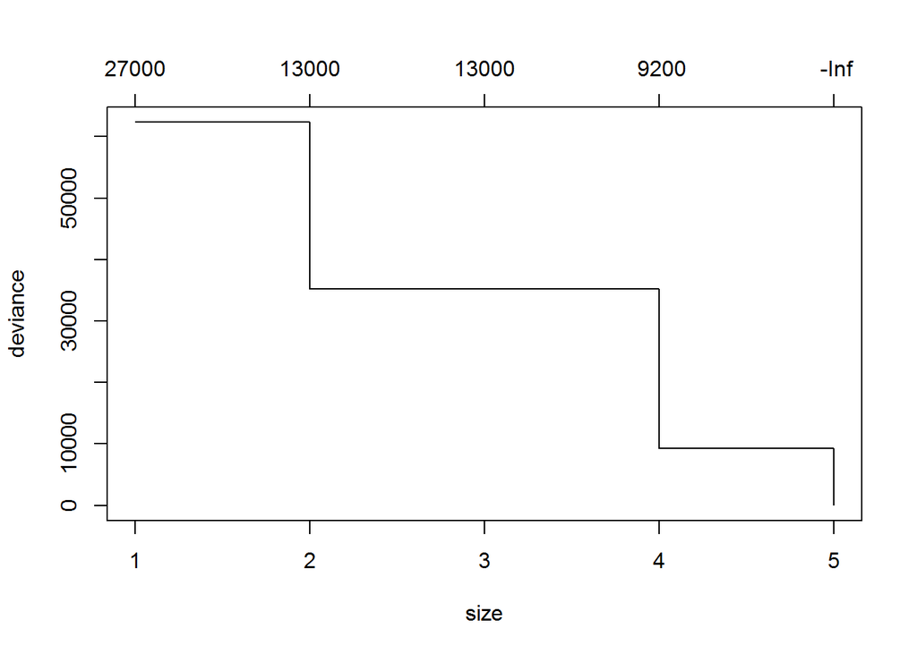

```r
cv.model <- cv.tree(tree.model)
plot(cv.model)
```

##### **Gives the deviance for each K**

```r
cv.model$dev
```

```
## [1]    55.26204  9238.89298 35166.66929 35166.66929 62322.98840
```

##### **Gives which size is better**

```r
best.size <- cv.model$size[which(cv.model$dev==min(cv.model$dev))]
best.size
```

```
## [1] 5
```

##### **Refit the tree model (the number of leafs will be no more than best.size)**

```r
cv.model.pruned <- prune.misclass(tree.model, best=best.size)
summary(cv.model.pruned)
```

```
##
## Classification tree:
## tree(formula = Answer ~ ., data = Tablec2)
## Variables actually used in tree construction:
## [1] "X"
## Number of terminal nodes:  5
## Residual mean deviance:  0 = 0 / 19620
## Misclassification error rate: 0 = 0 / 19622
```

## **Classification and Regression Trees: Trinity Manning-Pickett**

##### **Partition**

```r
Training1 <- sample(1:nrow(Tablec2), size= .8* nrow(Tablec2))
TrainingData <- Tablec2[Training1, ]
TestData <- Tablec2[-Training1, ]
```

##### **Create CART Model**

```r
set.seed(2224)
library(rpart)
rpart <- rpart(TrainingData$Answer~ . , data = TrainingData, method  = "class")
```

##### **Create and View Estimated Values of Model**

```r
getAnywhere(predict)
```

```
## A single object matching 'predict' was found
## It was found in the following places
##   package:stats
##   namespace:stats
## with value
##
## function (object, ...)
## UseMethod("predict")
## <bytecode: 0x00000000066f47c0>
## <environment: namespace:stats>
```

```r
Prediction <- predict(rpart, TestData, type = "vector")
View(Prediction)
```

##### **Substitute Numerical Values with Classifications**

```r
Prediction1 <- gsub(1, "A", Prediction)
Prediction2 <- gsub(2, "B", Prediction1)
Prediction3 <- gsub(3, "C", Prediction2)
Prediction4 <- gsub(4, "D", Prediction3)
Prediction5 <- gsub(5, "E", Prediction4)
```

##### **Check Classes of Test Data and Prediction Outputs**

```r
class(TestData$Answer)
```

```
## [1] "factor"
```

```r
class(Prediction5)
```

```
## [1] "character"
```

##### **Make Both Outputs Factors**

Test Data class is “factor”, while Prediction5 is “character”. Reformate Prediction from “character” to “factor”.

```r
Prediction6 <- as.factor(Prediction5)
```

##### **Using a Confusion Matrix**

```r
CM <- getAnywhere(confusionMatrix(Prediction6, TestData$Answer))
print(CM)
```

[output not shown]

## **randomForest Model: Ursula Eisinger**

##### **Set working directory.**

```r
getwd()
```

```
## [1] "C:/Users/Student/Desktop"
```

```r
setwd("C:/Users/Student/Desktop")
```

##### **Import training data and remove unnecessary columns**.

```r
original_train <- read.csv("training.csv")
new_train <- original_train[,c(2, 7:11, 37:49, 60:68, 84, 85, 86, 113:124, 140, 151:160)]
```

##### **Create answer column**.

```r
answer <- new_train[, 54]
```

##### **Import testing data and remove unnecessary columns.**

```r
original_test <- read.csv("testing.csv")
new_test <- original_test[,c(2, 7:11, 37:49, 60:68, 84, 85, 86, 113:124, 140, 151:159)]
```

##### **Ensures that the training and testing column names are the same.**

```r
column_c <- intersect(colnames(new_train), colnames(new_test))
Train0 <- new_train[, column_c]
Test1 <- new_test[, column_c]
Train1 <- cbind(Train0, answer)
```

##### **Partition the training data.**

```r
set.seed(123)
samplea <- floor(0.7 *nrow(Train1))
ind <- sample(seq_len(nrow(Train1)), size = samplea)
train_1 <- Train1[ind, ]
test_1 <- Train1[-ind, ]
```

##### **Build the Classification Model using the Random Forest package.**

```r
library(randomForest)
set.seed(222)
train_1$answer = as.factor(train_1$answer)
rf <-randomForest(answer~., data=train_1)
print(rf)
```

```
##
## Call:
##  randomForest(formula = answer ~ ., data = train_1)
##                Type of random forest: classification
##                      Number of trees: 500
## No. of variables tried at each split: 7
##
##         OOB estimate of  error rate: 0.28%
## Confusion matrix:
##      A    B    C    D    E class.error
## A 3922    0    0    0    1 0.000254907
## B    3 2680    3    0    0 0.002233805
## C    0   12 2354    0    0 0.005071851
## D    0    0   15 2237    2 0.007542147
## E    0    0    0    3 2503 0.001197127
```

```r
attributes(rf)
```

```
## $names
##  [1] "call"            "type"            "predicted"
##  [4] "err.rate"        "confusion"       "votes"
##  [7] "oob.times"       "classes"         "importance"
## [10] "importanceSD"    "localImportance" "proximity"
## [13] "ntree"           "mtry"            "forest"
## [16] "y"               "test"            "inbag"
## [19] "terms"
##
## $class
## [1] "randomForest.formula" "randomForest"
```

##### **Prediction and Confusion Matrix with the training data.**

```r
library(caret)
p1 <- predict(rf, train_1)
head(train_1$answer) ##check predictions on actual data
```

```
## [1] B D B E E A
## Levels: A B C D E
```

```r
confusionMatrix(p1, train_1$answer)
```

```
## Confusion Matrix and Statistics
##
##           Reference
## Prediction    A    B    C    D    E
##          A 3923    0    0    0    0
##          B    0 2686    0    0    0
##          C    0    0 2366    0    0
##          D    0    0    0 2254    0
##          E    0    0    0    0 2506
##
## Overall Statistics
##
##                Accuracy : 1
##                  95% CI : (0.9997, 1)
##     No Information Rate : 0.2856
##     P-Value [Acc > NIR] : < 2.2e-16
##
##                   Kappa : 1
##  Mcnemar's Test P-Value : NA
##
## Statistics by Class:
##
##                      Class: A Class: B Class: C Class: D Class: E
## Sensitivity            1.0000   1.0000   1.0000   1.0000   1.0000
## Specificity            1.0000   1.0000   1.0000   1.0000   1.0000
## Pos Pred Value         1.0000   1.0000   1.0000   1.0000   1.0000
## Neg Pred Value         1.0000   1.0000   1.0000   1.0000   1.0000
## Prevalence             0.2856   0.1956   0.1723   0.1641   0.1825
## Detection Rate         0.2856   0.1956   0.1723   0.1641   0.1825
## Detection Prevalence   0.2856   0.1956   0.1723   0.1641   0.1825
## Balanced Accuracy      1.0000   1.0000   1.0000   1.0000   1.0000
```

##### **Prediction and Confusion Matrix with the testing data (partitioned from training).**

```r
library(caret)
test_1 <- rbind(train_1[1, ] , test_1)  ##equalize train and test to remove non-matching predictor error
test_1 <- test_1[-1,]
p2 <- predict(rf, test_1)
confusionMatrix(p2, test_1$answer)
```

```
## Confusion Matrix and Statistics
##
##           Reference
## Prediction    A    B    C    D    E
##          A 1657    1    0    0    0
##          B    0 1110    9    0    0
##          C    0    0 1047    6    0
##          D    0    0    0  956    2
##          E    0    0    0    0 1099
##
## Overall Statistics
##
##                Accuracy : 0.9969
##                  95% CI : (0.9952, 0.9982)
##     No Information Rate : 0.2815
##     P-Value [Acc > NIR] : < 2.2e-16
##
##                   Kappa : 0.9961
##  Mcnemar's Test P-Value : NA
##
## Statistics by Class:
##
##                      Class: A Class: B Class: C Class: D Class: E
## Sensitivity            1.0000   0.9991   0.9915   0.9938   0.9982
## Specificity            0.9998   0.9981   0.9988   0.9996   1.0000
## Pos Pred Value         0.9994   0.9920   0.9943   0.9979   1.0000
## Neg Pred Value         1.0000   0.9998   0.9981   0.9988   0.9996
## Prevalence             0.2815   0.1887   0.1794   0.1634   0.1870
## Detection Rate         0.2815   0.1886   0.1778   0.1624   0.1867
## Detection Prevalence   0.2816   0.1901   0.1789   0.1627   0.1867
## Balanced Accuracy      0.9999   0.9986   0.9951   0.9967   0.9991
```

##### **Create graphs to show optimal tree number, tree nodes, and variable importance.**

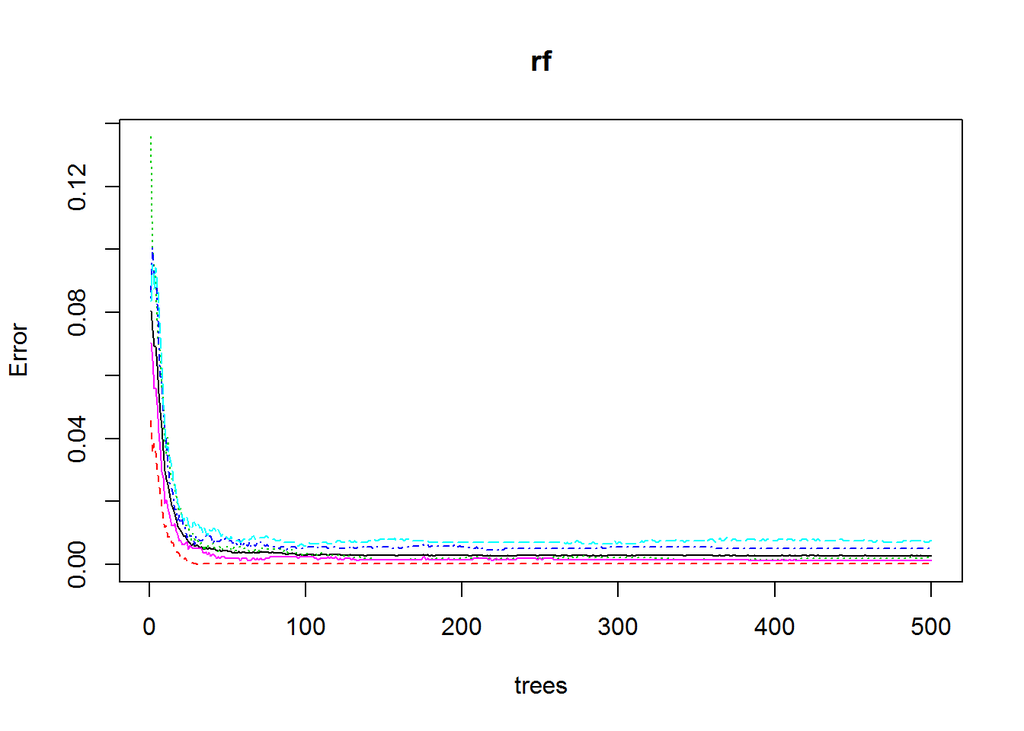

```r
plot(rf)
```

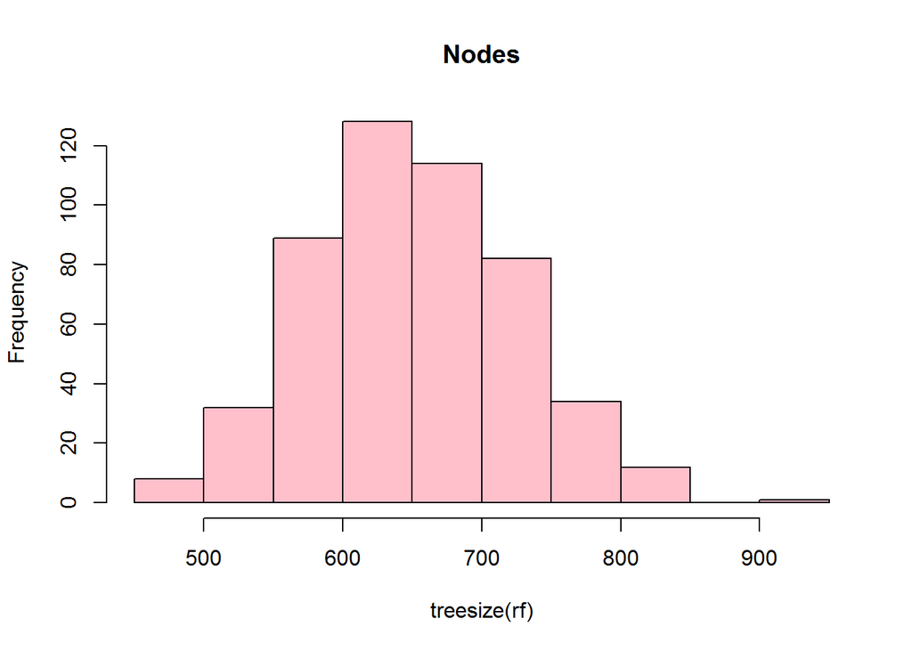

```r
hist(treesize(rf), main = 'Nodes', col = "pink")
```

```r
importance(rf)
```

```
##                     MeanDecreaseGini
## user_name                  124.30014
## num_window                 961.02240
## roll_belt                  818.60917
## pitch_belt                 463.42136
## yaw_belt                   569.81302
## total_accel_belt           157.29264
## gyros_belt_x                60.37653
## gyros_belt_y                74.02910
## gyros_belt_z               185.82020
## accel_belt_x                85.94703
## accel_belt_y                87.20938
## accel_belt_z               247.00768
## magnet_belt_x              169.99458
## magnet_belt_y              247.42886
## magnet_belt_z              252.35494
## roll_arm                   204.78923
## pitch_arm                  109.83857
## yaw_arm                    138.33722
## total_accel_arm             61.41624
## gyros_arm_x                 73.25021
## gyros_arm_y                 78.65563
## gyros_arm_z                 34.98541
## accel_arm_x                143.67865
## accel_arm_y                 88.97521
## accel_arm_z                 85.49726
## magnet_arm_x               159.98513
## magnet_arm_y               146.48149
## magnet_arm_z               107.25313
## roll_dumbbell              271.82242
## pitch_dumbbell             123.86529
## yaw_dumbbell               174.28306
## gyros_dumbbell_x            78.89039
## gyros_dumbbell_y           156.05368
## gyros_dumbbell_z            48.76746
## accel_dumbbell_x           186.98782
## accel_dumbbell_y           286.74222
## accel_dumbbell_z           236.39551
## magnet_dumbbell_x          322.33963
## magnet_dumbbell_y          461.10152
## magnet_dumbbell_z          480.90724
## roll_forearm               365.12656
## pitch_forearm              525.51396
## yaw_forearm                100.51724
## total_accel_forearm         64.09114
## gyros_forearm_x             45.18980
## gyros_forearm_y             74.73625
## gyros_forearm_z             51.06099
## accel_forearm_x            211.33546
## accel_forearm_y             78.64365
## accel_forearm_z            147.56917
## magnet_forearm_x           133.68042
## magnet_forearm_y           125.92566
## magnet_forearm_z           164.33449
```

##### **Prediction for the real test data.**

```r
library(caret)
p3 <- predict(rf, Test1)
print(p3)
```

```
##  1  2  3  4  5  6  7  8  9 10 11 12 13 14 15 16 17 18 19 20
##  B  A  B  A  A  E  D  B  A  A  B  C  B  A  E  E  A  B  B  B
## Levels: A B C D E
```

##### **Partition**

Split training data into subset training and testing group for building model

```r
set.seed(1234)
Training1 <- sample(1:nrow(Tablec2), size= .7* nrow(Tablec2))

TrainingData <- Tablec2[Training1, ]
TestData <- Tablec2[-Training1, ]
```

##### **Build Multi Model**

```r
library(nnet)
multimodel <- multinom(Answer~ . , data = TrainingData, maxit = 500, trace = T)
```

##### **Predict**

With testing data See what it looks like using the head function

```r
multipred1 <- predict(multimodel, type = "probs", newdata = TestData)
multipred2 <- predict(multimodel, type = "class", newdata = TestData)

head(multipred2, 5)
```

```
## [1] A A A A A
## Levels: A B C D E
```

```r
head(multipred1, 5)
```

```
##   A B C D E
## 1 1 0 0 0 0
## 2 1 0 0 0 0
## 3 1 0 0 0 0
## 4 1 0 0 0 0
## 5 1 0 0 0 0
```

##### **Prediction for the real test data.**

```r
library(caret)
p3 <- predict(rf, Test1)
print(p3)
```

```
##  1  2  3  4  5  6  7  8  9 10 11 12 13 14 15 16 17 18 19 20
##  B  A  B  A  A  E  D  B  A  A  B  C  B  A  E  E  A  B  B  B
## Levels: A B C D E
```